# SIS Ambiental: IA para o Licenciamento Ambiental

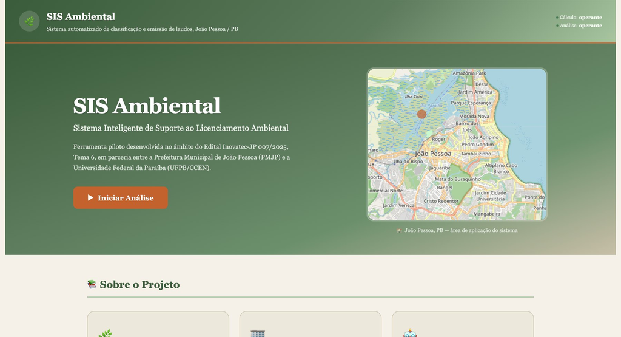

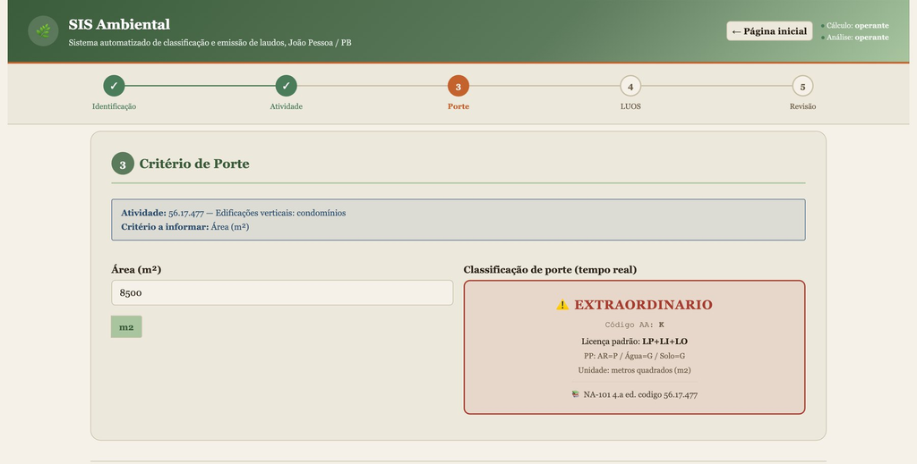

Telas reais do protótipo em operação

[figure not shown]

[figure not shown]

[figure not shown]

Universidade Federal da Paraíba

[figure not shown]

Departamento de Estatística

PROJETO DE PESQUISA · RESULTADOS

IA para o Licenciamento Ambiental

SIS Ambiental: porte, conformidade urbanística e laudo técnico calculados segundo a LUOS e a NA-101, em João Pessoa.

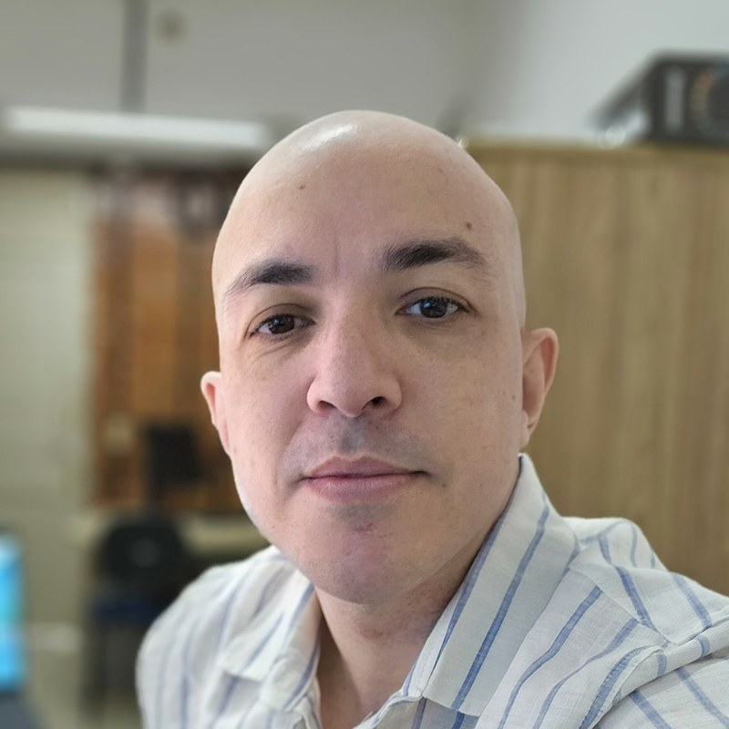

COORDENADOR

Prof. Dr. Pedro Rafael Diniz Marinho

Departamento de Estatística · CCEN/UFPB

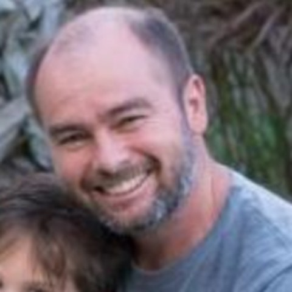

APRESENTAÇÃO

Prof. Dr. Joácio de Araújo Morais Júnior · Eng. Civil e Ambiental/UFPB

Contexto · O que é licenciar

Licenciar é autorizar, em etapas, quem pode impactar o ambiente

Instrumento da Política Nacional do Meio Ambiente (Lei nº 6.938/1981). Em João Pessoa, cada pedido é lido por duas lentes: a **cidade**, pela LUOS, e o **Estado**, pela NA-101 da Sudema.

LP

Fase de planejamento

Licença Prévia

Aprova a localização e a concepção do empreendimento e atesta sua viabilidade ambiental.

LI

Fase de obra

Licença de Instalação

Autoriza a instalação conforme os projetos aprovados e as medidas de controle ambiental.

LO

Fase de funcionamento

Licença de Operação

Autoriza a operação depois de verificado o cumprimento do que as licenças anteriores exigiram.

**Prazo legal de análise:** até 6 meses; até 12 meses quando há EIA/RIMA ou audiência pública (NA-101, item 4.5).

**No nosso exemplo:** o condomínio vertical exige as três de uma vez, no pacote LP+LI+LO.

Fontes: Lei nº 6.938/1981; Resolução CONAMA nº 237/1997; NA-101/Sudema, 4ª ed., itens 3 e 4.5.

SIS Ambiental · INOVATEC-JP 007/2025 · UFPB

02

O desafio

Licenciar exige cruzar normas extensas, processo a processo

1

Duas normas obrigatórias ao mesmo tempo

A LUOS (LC 166/2024) define o que pode ser construído em cada zona; a NA-101/Sudema define porte, licença e custo de cada atividade.

2

Análise manual e demorada

Tabelas consultadas uma a uma e contas feitas à mão: risco de erro e de interpretações diferentes entre analistas.

3

Muitas idas a campo

Vistorias só para confirmar localização, zona de uso e parâmetros do lote, que poderiam ser checados no escritório.

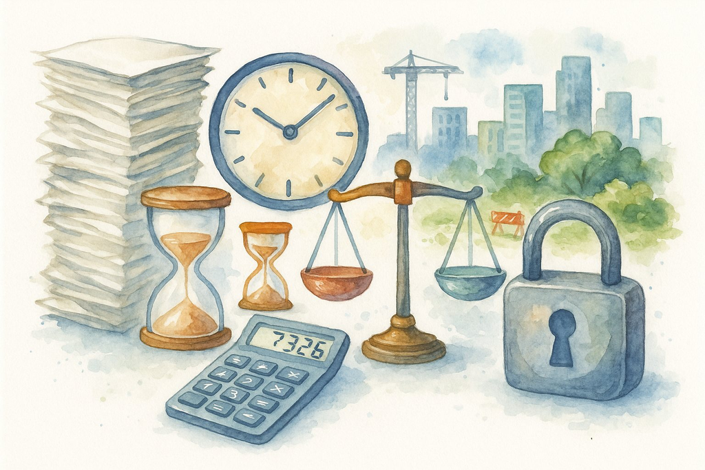

O gargalo: papel, prazo e insegurança jurídica

623

atividades na NA-101

21

zonas de uso na LUOS

SIS Ambiental · INOVATEC-JP 007/2025 · UFPB

03

Contexto · O rito do licenciamento

Os 8 passos da NA-101 e onde o SIS Ambiental atua

1

Requerimento

Interessado entrega o pedido e a documentação da atividade.

SIS: IA pré-preenche a partir de documentos

2

Análise e enquadramento

Corpo técnico analisa, enquadra a atividade e faz vistorias.

SIS: Enquadramento, porte, LUOS e triagem de vistorias

3

Complementações

Sudema pede esclarecimentos e define competências, quando couber.

4

EIA/RIMA

Casos de grande impacto: comissão multidisciplinar e audiência pública.

5

Parecer técnico

Emissão do parecer técnico conclusivo.

SIS: Laudo com fundamentação e rastreabilidade

6

Decisão

Concessão ou indeferimento da licença ambiental.

7

Comunicação

Resposta motivada ao requerente em caso de indeferimento.

8

Publicação

Publicação do resultado do licenciamento.

**Objetivo geral do projeto:** agilizar o licenciamento em João Pessoa automatizando os cálculos e a análise de conformidade com a LUOS e a NA-101, otimizando o trabalho de campo das equipes.

Fontes: NA-101/Sudema, 4ª ed., item 4.4; Projeto INOVATEC-JP 007/2025, seção 4.1 (Objetivo Geral). Em destaque, as etapas que o sistema acelera.

SIS Ambiental · INOVATEC-JP 007/2025 · UFPB

04

A PROPOSTA

Um sistema de IA que lê a norma, faz as contas e redige o laudo, com cada número ligado ao artigo que o fundamenta.

INOVATEC-JP 007/2025 · Tema 6

PMJP + UFPB

Protótipo concluído

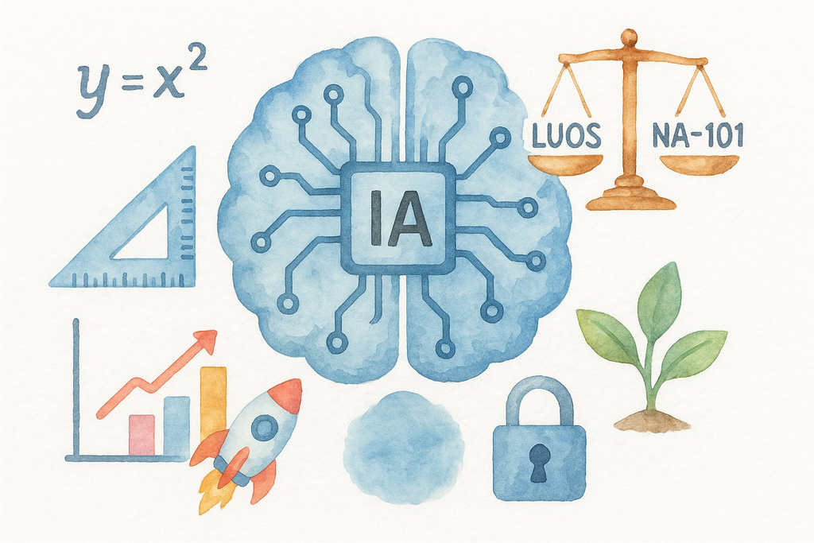

IA + LUOS + NA-101: a norma vira regra de cálculo

SIS Ambiental · INOVATEC-JP 007/2025 · UFPB

05

Como funciona

Do requerimento ao laudo: o caminho dentro do SIS Ambiental

NÚCLEO DE INTELIGÊNCIA

1

Entrada

Técnico preenche 5 passos

Dados, atividade, porte e lote. A IA pode pré-preencher a partir do documento de vistoria.

2

Motor de regras

Aplica LUOS e NA-101

Classifica porte e licença, confere índices e recuos e calcula o valor em UFRPB.

3

IA de linguagem

Redige o laudo

Escreve o texto técnico a partir dos resultados e cita cada artigo. Não inventa números.

4

Laudo em PDF

Documento auditável

Mapa, imagem de satélite, fundamentação e tabela de rastreabilidade.

5

Decisão

O técnico decide

Revisa e confirma; a fiscalização vai a campo só onde há indício de problema.

**Base normativa codificada** LUOS: 21 zonas · NA-101: 623 atividades

**Regra de ouro:** nenhum cálculo pode contrariar a LUOS ou a NA-101. A IA escreve; quem calcula é o motor de regras.

SIS Ambiental · INOVATEC-JP 007/2025 · UFPB

06

O sistema em funcionamento · Tela inicial

A porta de entrada do SIS Ambiental

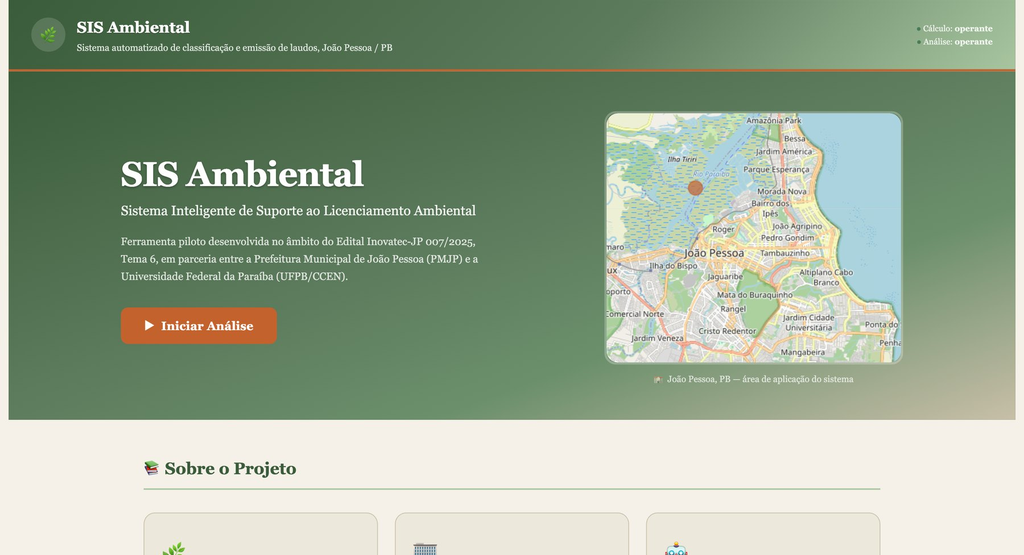

Tela inicial do SIS Ambiental (captura do sistema em operação)

1

2

3

1

Botão Iniciar Análise

Um clique abre o passo a passo de um novo licenciamento.

2

Mapa de João Pessoa

A área de aplicação do sistema: todo processo é georreferenciado.

3

Serviços em operação

Os indicadores mostram que o cálculo e a análise por IA estão no ar.

MENSAGEM-CHAVE

Não é maquete: é o sistema real, pronto para o técnico da Prefeitura.

SIS Ambiental · INOVATEC-JP 007/2025 · UFPB

07

Passo 1 de 5 · Identificação

Quem é o requerente e onde fica o empreendimento

[figure not shown]

Passo 1: dados do requerente e localização no mapa

1

2

3

4

1

CNPJ validado na hora

O sistema confere os dígitos e evita erros de cadastro.

2

Endereço localizado

Digitou o endereço, o sistema encontra o local sozinho.

3

Mapa e coordenadas

Posição exata do terreno, aqui na orla do Cabo Branco.

4

Passos guiados

A barra mostra em qual das 5 etapas o técnico está.

MENSAGEM-CHAVE

A localização precisa é o que permite analisar a área sem sair do escritório.

SIS Ambiental · INOVATEC-JP 007/2025 · UFPB

08

Passo 2 de 5 · Atividade

Enquadramento na NA-101 em três escolhas

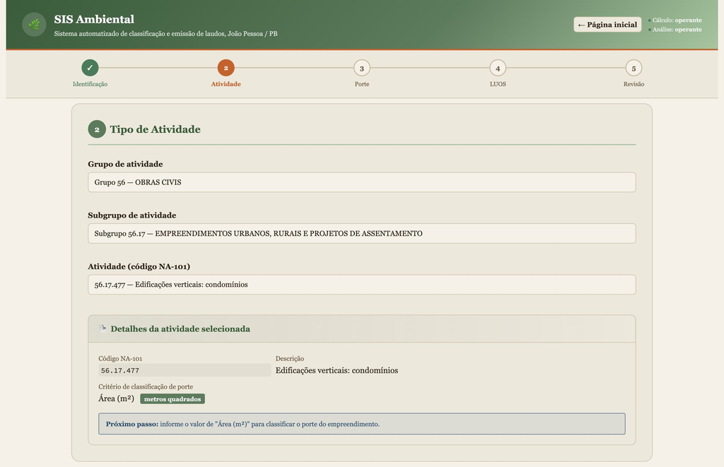

Passo 2: escolha da atividade na hierarquia da NA-101

1

2

3

4

1

Grupo

Obras Civis. Listas fechadas, sem texto livre, sem ambiguidade.

2

Subgrupo

Empreendimentos urbanos, rurais e de assentamento.

3

Código NA-101

56.17.477: edificações verticais (condomínios), entre 623 códigos.

4

Critério de porte

O sistema já avisa o que medir: aqui, área em m².

MENSAGEM-CHAVE

O que exigia folhear a tabela da norma agora são três cliques.

SIS Ambiental · INOVATEC-JP 007/2025 · UFPB

09

Passo 3 de 5 · Porte

Porte, licença e potencial poluidor em tempo real

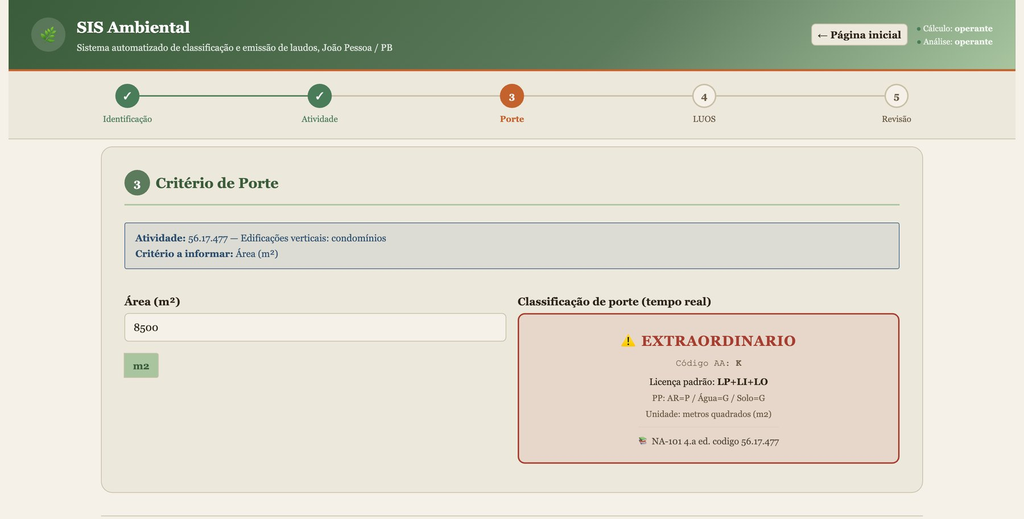

Passo 3: classificação de porte calculada na hora

1

2

3

1

Valor do critério

8.500 m² de área do empreendimento.

2

Porte classificado

Extraordinário, código AA K, conforme a NA-101.

3

Licença e poluição

Exige LP+LI+LO. Potencial poluidor: ar pequeno; água e solo grandes.

MENSAGEM-CHAVE

Enquanto o técnico digita, o sistema já mostra o impacto ambiental da atividade.

SIS Ambiental · INOVATEC-JP 007/2025 · UFPB

10

Por dentro da NA-101 · Enquadramento

Como a norma classifica uma atividade: o caso 56.17.477

EDIFICAÇÕES VERTICAIS: CONDOMÍNIOS · ANEXO J

Porte

Área (m²)

Letra

Ar / Água / Solo

Micro

menor que 500

F

P / P / P

Pequeno

500 a 1.000

H

P / P / M

Médio

1.000 a 3.000

I

P / M / M

Grande

3.000 a 5.000

J

P / M / G

Extraordinário

5.000 ou mais

K

P / G / G

← 8.500 m²

O **potencial poluidor** cresce com o porte: o risco para água e solo passa de pequeno a grande. Por isso o sistema mostra os três meios em tempo real.

Código da atividade

56.17.477

Critério de porte

área, em m²

Porte

Extraordinário

Letra de custo

K

Valor da licença

316,8 UFRPB (LP+LI+LO)

Fonte: NA-101/Sudema, 4ª ed., Anexos J (cód. 56.17.477) e B. PP: P pequeno · M médio · G grande.

SIS Ambiental · INOVATEC-JP 007/2025 · UFPB

11

Por dentro da LUOS · Lei Complementar nº 166/2024

O que a LUOS exige do lote: zona, índices e recuos

AS ZONAS DA CIDADE (ART. 7º)

ZH 1–5 · Habitacionais

ZCS 1–7 · Comércio e serviços

ZEPA 1–3 · Proteção ambiental

ZI 1–2 · Industriais

ZBD · Baixa densidade

ZDTRL · ZDTRS · Resíduos

SEAV · Áreas verdes

Onde a lei protege o ambiente

**ZEPA-1:** falésias, manguezais, restingas, Mata do Buraquinho e parques (Art. 27).

**ZEPA-2:** nenhuma construção na faixa de 100 m das falésias (Art. 28).

**ZH-3:** faixa de restrição de 500 m da orla marítima (Art. 12).

IA

Índice de Aproveitamento

LUOS

Área construída computável ÷ área do lote. Básico igual a 1,0 em toda a cidade.

TO

Taxa de Ocupação

LUOS · Anexo V

Projeção da edificação ÷ área do lote. Na ZH-2, no máximo 55%.

RP

Recuo progressivo

LUOS · Anexo V

Recuo lateral cresce com a altura: RP = 3 + (N − 4) × 0,3. No 6º pavimento, 3,60 m.

São exatamente estes três testes que o sistema faz no Passo 4, a seguir.

Fonte: LC nº 166/2024 (LUOS de João Pessoa), arts. 7º, 12, 27 e 28 e Anexo V (parâmetros de ocupação).

SIS Ambiental · INOVATEC-JP 007/2025 · UFPB

12

Passo 4 de 5 · LUOS

Conformidade urbanística verificada antes de ir a campo

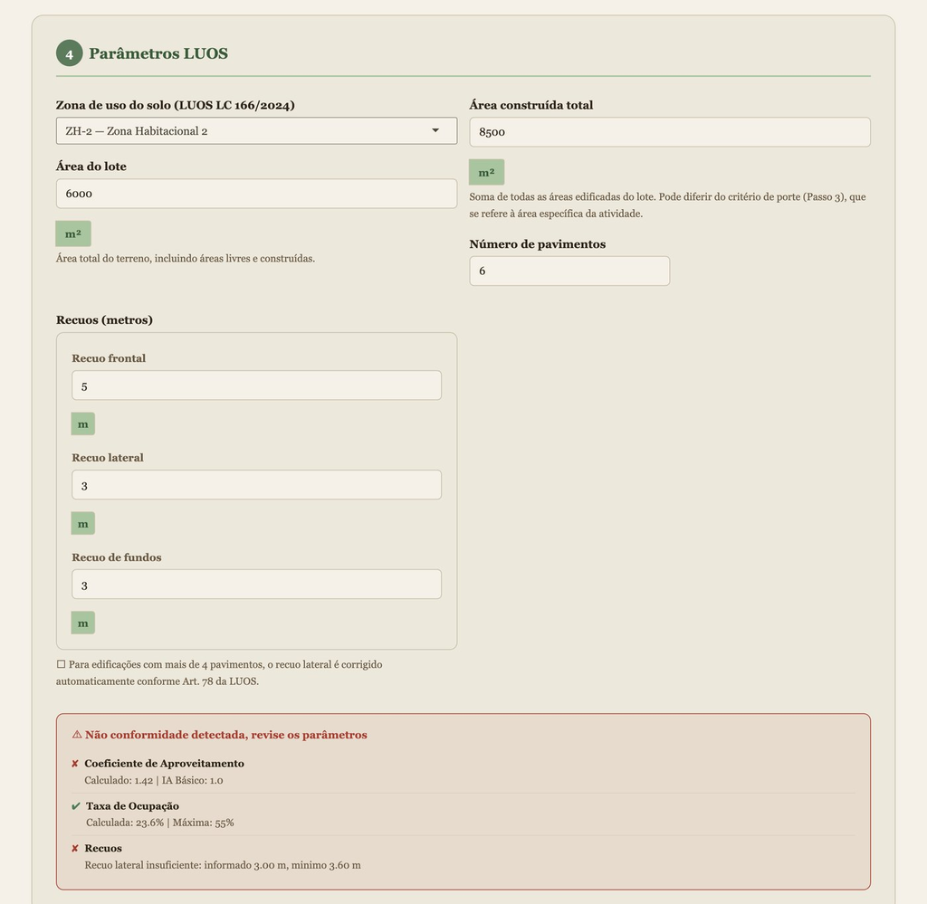

Passo 4: parâmetros do lote (zona ZH-2)

1

2

3

ANTES · Não conforme

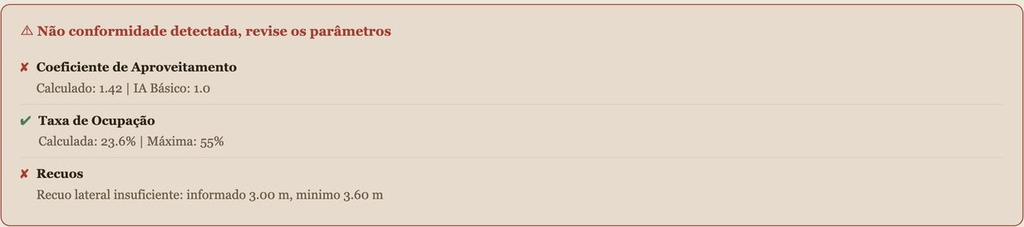

DEPOIS DO AJUSTE · Conforme

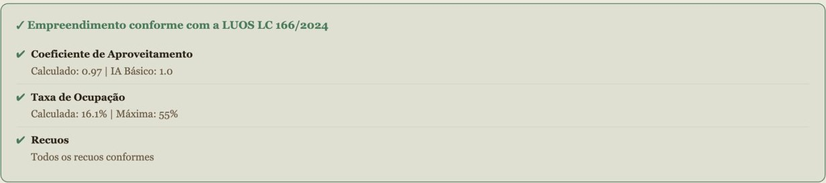

1

Zona de uso

ZH-2 define os limites do lote.

2

Recuo lateral

3 m informados; mínimo de 3,60 m (Art. 78).

3

Alerta automático

Mostra o valor calculado, o limite e o artigo.

SIS Ambiental · INOVATEC-JP 007/2025 · UFPB

13

Passo 5 de 5 · Revisão

O técnico confere tudo antes de emitir

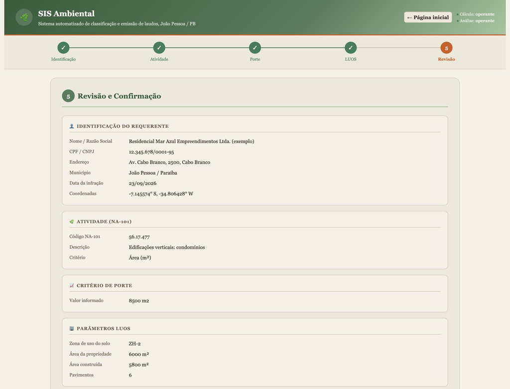

Passo 5: revisão de todos os dados antes da emissão

1

2

3

4

1

Requerente e localização

Nome, CNPJ, endereço e coordenadas num só quadro.

2

Atividade e porte

Código NA-101 e valor do critério informado.

3

Parâmetros urbanísticos

Zona, área do lote, área construída e pavimentos.

4

Confirmação final

Só depois dela o sistema calcula e redige o laudo.

MENSAGEM-CHAVE

A IA apoia; quem decide é o técnico.

SIS Ambiental · INOVATEC-JP 007/2025 · UFPB

14

Resultado

Classificação e laudo redigidos em segundos

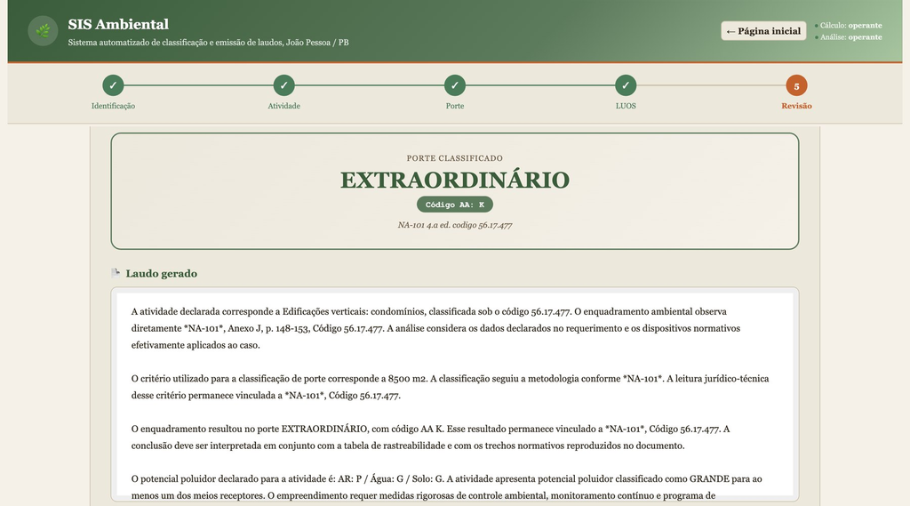

Resultado: porte e texto técnico gerados após a confirmação

1

2

1

Porte classificado

Extraordinário, código AA K, com a referência exata na NA-101.

2

Texto do laudo

Redigido pela IA a partir dos cálculos, citando NA-101 e LUOS.

MENSAGEM-CHAVE

≈ 3 segundos para o resultado; PDF completo em menos de 1 minuto.

SIS Ambiental · INOVATEC-JP 007/2025 · UFPB

15

O produto final

O laudo técnico emitido pelo sistema: 8 páginas

[figure not shown]

1

Capa e objeto

Requerente, atividade, licença e porte em destaque.

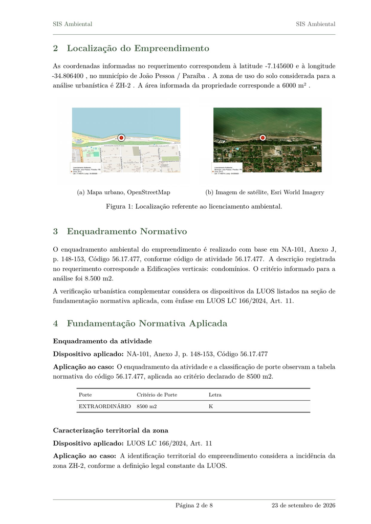

2

Localização

Mapa urbano e imagem de satélite do terreno.

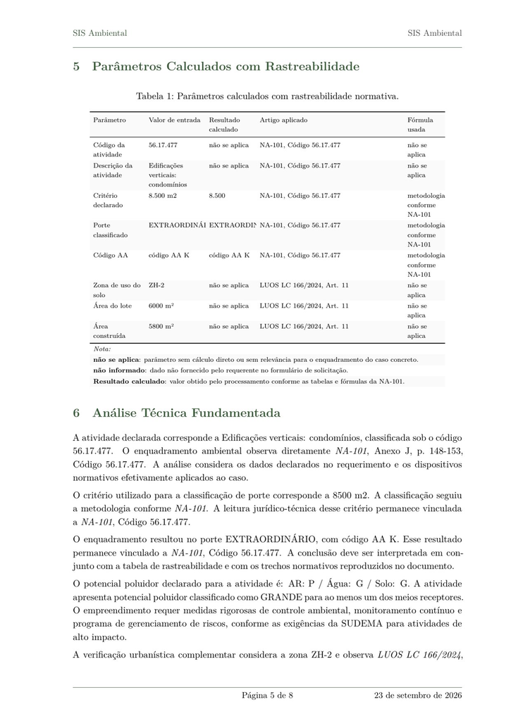

3

Rastreabilidade

Cada parâmetro com o artigo que o justifica.

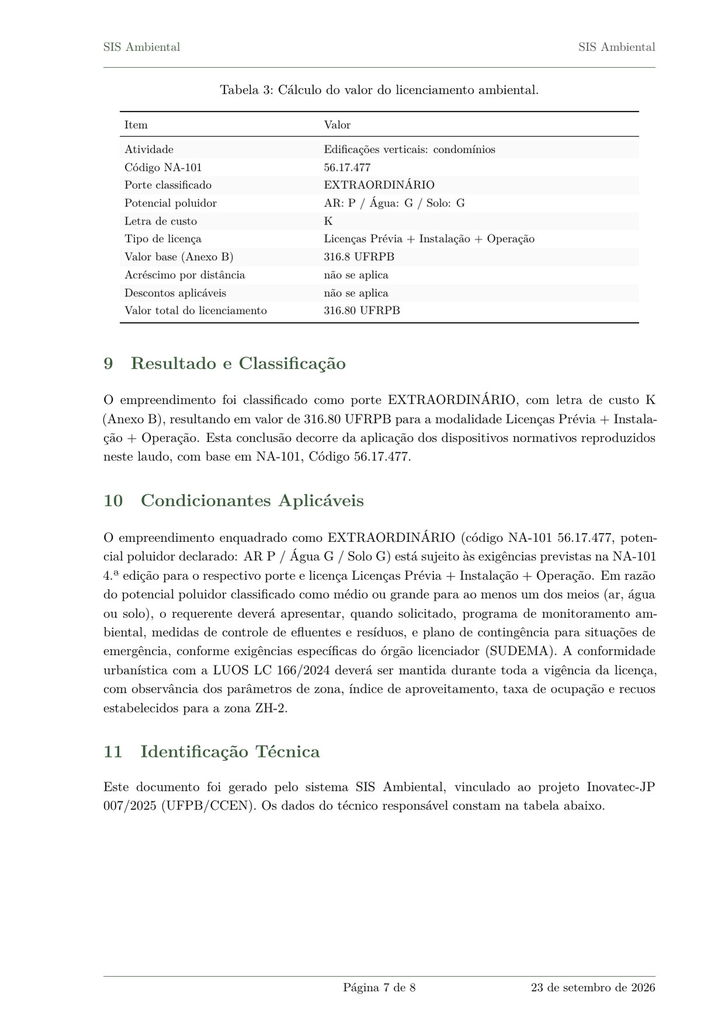

4

Valor da licença

Cálculo em UFRPB, passo a passo: 316,8 UFRPB.

SIS Ambiental · INOVATEC-JP 007/2025 · UFPB

16

Vantagens para a gestão ambiental

O que muda para a Prefeitura

1

Rapidez na análise dos processos

≈ 3 s

para enquadrar, verificar a LUOS e redigir o laudo

O que hoje exige tabelas e contas manuais sai padronizado e pronto para revisão. Meta do projeto: até 70% menos tempo nos processos de baixa e média complexidade.

2

Menos visitas de campo

Triagem remota

localização, zona e parâmetros conferidos no escritório

Mapa e satélite no laudo e não conformidades apontadas: a fiscalização vai a campo onde há indício de problema, não para confirmar o que os dados já mostram.

Transparência: cada número cita o artigo

Padronização entre analistas

Segurança jurídica

SIS Ambiental · INOVATEC-JP 007/2025 · UFPB

17

Resultados do protótipo

Testado em escala antes de chegar ao balcão

250

laudos-teste gerados de ponta a ponta, do formulário ao PDF

10

grupos de atividades da NA-101 cobertos nos testes

623

atividades da NA-101 codificadas no motor de cálculo

21

zonas de uso da LUOS parametrizadas

Cada laudo-teste foi conferido quanto ao texto, à tabela de rastreabilidade e ao valor em UFRPB, com revisão de especialista; as correções foram incorporadas ao sistema. Em **96 dos 250 casos**, a verificação urbanística da LUOS também foi aplicada.

SIS Ambiental · INOVATEC-JP 007/2025 · UFPB

18

Equipe

Quem desenvolveu o SIS Ambiental

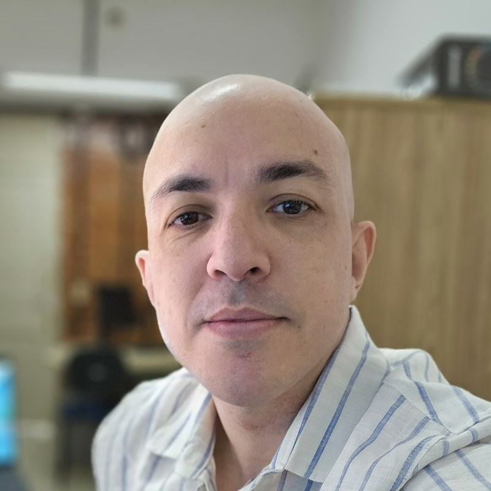

COORDENADOR

Pedro Rafael Diniz Marinho

Estatística · CCEN/UFPB

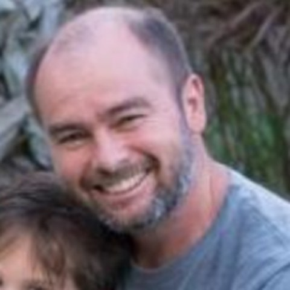

Joácio de Araújo Morais Júnior